# BookVision — Núcleo algorítmico

**TFM: Sistema de Reconocimiento Automático de Libros mediante Visión Artificial y Aprendizaje Profundo** Antonio Álvarez Velasco — Máster en Ciencia de Datos (UCJC) — dirigido por Anas Ahachad

Este notebook contiene, de forma autocontenida, el algoritmo end-to-end y los experimentos que justifican sus decisiones de diseño: el objeto de estudio de este TFM. No incluye interfaz de usuario, persistencia en base de datos ni empaquetado como aplicación, por no ser el objeto de estudio de este trabajo (ver "Trabajo futuro" al final del notebook).

## Qué hace el sistema

A partir de una fotografía de la portada de un libro:

1. **Preprocesa** la imagen (OpenCV): endereza, elimina ruido, mejora contraste.
2. **Lee el texto** con OCR (EasyOCR / PaddleOCR).
3. **Extrae campos** (título, autor, ISBN) a partir de las líneas detectadas, usando el tamaño de letra y la posición de cada línea.
4. Calcula una **huella visual** de la portada con una CNN preentrenada (transfer learning), para reconocer si ya se había visto ese libro.
5. Compara el texto leído con metadatos de **Google Books / Open Library** y calcula una puntuación de confianza (*fuzzy matching*).
6. Clasifica el resultado en tres niveles: identificación automática, posible coincidencia (revisión manual) o no identificado.

Cada sección de este notebook implementa y ejecuta en vivo una de estas etapas sobre imágenes del dataset sintético de ejemplo, y la última sección reproduce los 5 experimentos de evaluación con sus gráficas.

```python
import warnings
warnings.filterwarnings("ignore")

from pathlib import Path

import cv2
import numpy as np
import pandas as pd
import matplotlib.pyplot as plt

%matplotlib inline
plt.rcParams["figure.dpi"] = 110

# Este notebook asume que se ejecuta con la raíz de este repositorio como
# directorio de trabajo (ábrelo con Jupyter desde ahí).
DATA_DIR = Path("data/synthetic_samples")
RESULTS_DIR = Path("results")
assert DATA_DIR.exists(), (
    "No se encuentra data/synthetic_samples: ejecuta Jupyter desde la raíz "
    "de este repositorio, no desde una subcarpeta."
)

sorted(p.name for p in DATA_DIR.glob("*.png"))
```

```
['00_frontal.png',
 '00_perspectiva.png',
 '00_poca_luz.png',
 '00_reflejo.png',
 '00_rotada.png',
 '01_frontal.png',
 '01_perspectiva.png',
 '01_poca_luz.png',
 '01_reflejo.png',
 '01_rotada.png',
 '02_frontal.png',
 '02_perspectiva.png',
 '02_poca_luz.png',
 '02_reflejo.png',
 '02_rotada.png']
```

## Datos de ejemplo

El dataset sintético completo (75 imágenes: 15 títulos × 5 condiciones de captura — frontal, rotada, poca luz, con reflejo, en perspectiva) se generó mediante un script de generación sintética (composición de texto renderizado con transformaciones geométricas y fotométricas controladas). Aquí se incluye una muestra de **3 títulos × 5 condiciones = 15 imágenes** suficiente para demostrar cada etapa del algoritmo sin necesitar el dataset completo. Los tres títulos son *Cien años de soledad* (Gabriel García Márquez), *Don Quijote de la Mancha* (Miguel de Cervantes) y *1984* (George Orwell) — libros reales usados solo como texto de referencia; las portadas son renders sintéticos, no imágenes reales con derechos de autor.

## 1. Preprocesamiento de imagen (OpenCV)

Antes del OCR, la imagen se pasa por una cadena de operaciones clásicas de visión artificial: redimensionado, corrección de perspectiva y recorte automático de la portada (detección de contorno + `warpPerspective`), corrección de inclinación residual (*deskew*, vía transformada de Hough), reducción de ruido preservando bordes (filtro bilateral) y mejora de contraste local (CLAHE). El Experimento 1 (sección 8) cuantifica cuánto ayuda realmente cada motor OCR con este preprocesado.

```python
def resize(image, max_dimension=1600):
    h, w = image.shape[:2]
    scale = max_dimension / max(h, w)
    if scale >= 1.0:
        return image
    new_size = (int(w * scale), int(h * scale))
    return cv2.resize(image, new_size, interpolation=cv2.INTER_AREA)


def to_grayscale(image):
    if len(image.shape) == 2:
        return image
    return cv2.cvtColor(image, cv2.COLOR_BGR2GRAY)


def denoise(gray):
    return cv2.bilateralFilter(gray, d=7, sigmaColor=50, sigmaSpace=50)


def enhance_contrast(gray):
    clahe = cv2.createCLAHE(clipLimit=2.5, tileGridSize=(8, 8))
    return clahe.apply(gray)


def _order_points(pts):
    # Ordena 4 puntos como (superior-izq, superior-der, inferior-der, inferior-izq)
    pts = pts.reshape(4, 2)
    s = pts.sum(axis=1)
    diff = np.diff(pts, axis=1).flatten()
    tl, br = pts[np.argmin(s)], pts[np.argmax(s)]
    tr, bl = pts[np.argmin(diff)], pts[np.argmax(diff)]
    return np.array([tl, tr, br, bl], dtype="float32")


def _find_cover_quad(image, min_area_ratio=0.25):
    # Busca el contorno rectangular mas grande (la portada) sobre un fondo
    # distinguible; si no lo encuentra (p. ej. la portada ocupa ya todo el
    # encuadre), devuelve None y el resto del pipeline sigue sin recortar.
    gray = cv2.cvtColor(image, cv2.COLOR_BGR2GRAY)
    blurred = cv2.GaussianBlur(gray, (5, 5), 0)
    edges = cv2.dilate(cv2.Canny(blurred, 40, 120), np.ones((5, 5), np.uint8), iterations=1)
    contours, _ = cv2.findContours(edges, cv2.RETR_EXTERNAL, cv2.CHAIN_APPROX_SIMPLE)
    if not contours:
        return None
    image_area = image.shape[0] * image.shape[1]
    for c in sorted(contours, key=cv2.contourArea, reverse=True)[:5]:
        peri = cv2.arcLength(c, True)
        approx = cv2.approxPolyDP(c, 0.02 * peri, True)
        if len(approx) == 4 and cv2.contourArea(approx) >= min_area_ratio * image_area:
            return approx
    return None


def autocrop_perspective(image):
    """Detecta el contorno de la portada y corrige perspectiva con
    warpPerspective. Si no se encuentra un contorno rectangular fiable
    (p. ej. fondo poco distinguible), devuelve la imagen original sin
    modificar — no fuerza un recorte de baja confianza."""
    quad = _find_cover_quad(image)
    if quad is None:
        return image, False
    tl, tr, br, bl = _order_points(quad)
    max_width = int(max(np.linalg.norm(br - bl), np.linalg.norm(tr - tl)))
    max_height = int(max(np.linalg.norm(tr - br), np.linalg.norm(tl - bl)))
    dst = np.array([[0, 0], [max_width - 1, 0], [max_width - 1, max_height - 1], [0, max_height - 1]], dtype="float32")
    matrix = cv2.getPerspectiveTransform(np.array([tl, tr, br, bl], dtype="float32"), dst)
    warped = cv2.warpPerspective(image, matrix, (max_width, max_height))
    return warped, True


def estimate_skew_angle(gray):
    edges = cv2.Canny(gray, 50, 150, apertureSize=3)
    lines = cv2.HoughLinesP(
        edges, 1, np.pi / 180, threshold=100,
        minLineLength=gray.shape[1] // 4, maxLineGap=20,
    )
    if lines is None or len(lines) == 0:
        return 0.0
    angles = []
    for line in lines:
        x1, y1, x2, y2 = line[0]
        if x2 == x1:
            continue
        angle = np.degrees(np.arctan2(y2 - y1, x2 - x1))
        if -45 < angle < 45:
            angles.append(angle)
    return float(np.median(angles)) if angles else 0.0


def deskew(image, angle=None):
    gray = to_grayscale(image)
    if angle is None:
        angle = estimate_skew_angle(gray)
    if abs(angle) < 0.5:
        return image
    h, w = image.shape[:2]
    matrix = cv2.getRotationMatrix2D((w // 2, h // 2), angle, 1.0)
    return cv2.warpAffine(image, matrix, (w, h), flags=cv2.INTER_CUBIC, borderMode=cv2.BORDER_REPLICATE)


def preprocess_for_ocr(image, *, do_autocrop=True, do_deskew=True, do_denoise=True, do_contrast=True):
    result = resize(image)
    if do_autocrop:
        result, _ = autocrop_perspective(result)
    if do_deskew:
        result = deskew(result)
    gray = to_grayscale(result)
    if do_denoise:
        gray = denoise(gray)
    if do_contrast:
        gray = enhance_contrast(gray)
    return gray
```

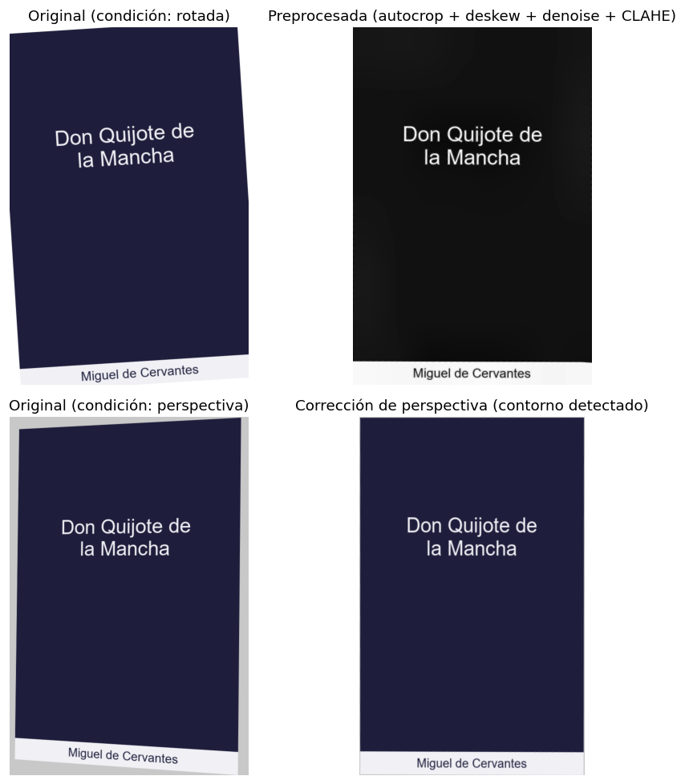

```python
ejemplo_path = DATA_DIR / "01_rotada.png"
imagen_original = cv2.imread(str(ejemplo_path), cv2.IMREAD_COLOR)
imagen_preprocesada = preprocess_for_ocr(imagen_original)

perspectiva_path = DATA_DIR / "01_perspectiva.png"
imagen_perspectiva = cv2.imread(str(perspectiva_path), cv2.IMREAD_COLOR)
imagen_recortada, encontrado = autocrop_perspective(imagen_perspectiva)

fig, axes = plt.subplots(2, 2, figsize=(9, 9))
axes[0, 0].imshow(cv2.cvtColor(imagen_original, cv2.COLOR_BGR2RGB))
axes[0, 0].set_title("Original (condición: rotada)")
axes[0, 1].imshow(imagen_preprocesada, cmap="gray")
axes[0, 1].set_title("Preprocesada (autocrop + deskew + denoise + CLAHE)")
axes[1, 0].imshow(cv2.cvtColor(imagen_perspectiva, cv2.COLOR_BGR2RGB))
axes[1, 0].set_title("Original (condición: perspectiva)")
axes[1, 1].imshow(cv2.cvtColor(imagen_recortada, cv2.COLOR_BGR2RGB))
axes[1, 1].set_title(f"Corrección de perspectiva (contorno {'detectado' if encontrado else 'NO detectado'})")
for ax in axes.flat:
    ax.axis("off")
plt.tight_layout()
plt.show()
```

## 2. OCR: lectura del texto de la portada

El sistema soporta dos motores intercambiables, **EasyOCR** y **PaddleOCR** (ambos instalables solo con `pip`, a diferencia de Tesseract), para poder compararlos experimentalmente (Experimento 2). Ejecutar cualquiera de los dos motores implica cargar un modelo de varios cientos de MB, lo cual no es necesario para revisar el algoritmo: por eso esta celda reutiliza el texto ya extraído por el pipeline real (`results/ocr_raw_results.csv`, generado por `experiments/run_ocr_benchmark.py` sobre las 75 imágenes del dataset sintético). Si tienes `paddleocr` instalado, la celda siguiente (opcional) ejecuta el motor en vivo sobre una imagen real.

```python
ocr_raw = pd.read_csv(RESULTS_DIR / "ocr_raw_results.csv")

ejemplo = ocr_raw[
    (ocr_raw.book_index == 1) & (ocr_raw.condition == "rotada")
    & (ocr_raw.engine == "paddleocr") & (ocr_raw.preprocessing == True)
].iloc[0]

print(f"Título real:      {ejemplo.title_truth}")
print(f"Autor real:       {ejemplo.author_truth}")
print(f"Texto OCR crudo:  {ejemplo.raw_text}")
print(f"Confianza media:  {ejemplo.mean_confidence:.2%}")
print(f"Tiempo OCR:       {ejemplo.elapsed_ocr_s:.3f} s")
```

```
Título real:      Don Quijote de la Mancha
Autor real:       Miguel de Cervantes
Texto OCR crudo:  Don Quijote de | la Mancha | Miguel de Cervantes
Confianza media:  96.26%
Tiempo OCR:       0.200 s
```

```python
# Celda OPCIONAL: ejecución en vivo de PaddleOCR sobre una imagen real.
# Se ejecuta solo si el paquete está instalado; si no, se omite sin error
# (el resto del notebook no depende de esta celda). Se guardan las líneas
# CON su bounding box (posición de cada esquina) porque la sección 3 las
# necesita para demostrar la extracción de campos basada en layout.
PADDLEOCR_DISPONIBLE = False
try:
    from paddleocr import PaddleOCR
    import time

    reader = PaddleOCR(use_angle_cls=True, lang="latin", show_log=False)
    imagen = cv2.imread(str(DATA_DIR / "01_rotada.png"), cv2.IMREAD_COLOR)  # misma imagen que "ejemplo" más abajo

    t0 = time.perf_counter()
    resultado = reader.ocr(imagen, cls=True)
    elapsed = time.perf_counter() - t0

    paddle_bbox_lines = [
        {"text": texto, "confidence": round(conf, 3), "bbox": bbox}
        for bbox, (texto, conf) in resultado[0]
    ]
    PADDLEOCR_DISPONIBLE = True
    print(f"PaddleOCR real ejecutado en {elapsed:.2f} s. Líneas detectadas:")
    for linea in paddle_bbox_lines:
        print(f"  [{linea['confidence']:.2f}] {linea['text']}")
except Exception as exc:
    print(f"PaddleOCR no disponible en este entorno ({exc!r}): se omite la ejecución en vivo "
          f"(la sección 2 ya muestra el resultado real precomputado; la sección 3 usará "
          f"solo la variante sin layout).")
```

```
PaddleOCR real ejecutado en 0.75 s. Líneas detectadas:
  [0.99] Don Quijote de
  [0.91] la Mancha
  [1.00] Miguel de Cervantes
```

## 3. Extracción de campos: ¿qué línea es el título?

Aquí se muestra la variante que opera solo sobre texto plano (usada cuando no se dispone de las cajas del OCR, p. ej. al reanalizar texto ya guardado).

```python
import re
import unicodedata

_PUNCT_RE = re.compile(r"[^\w\s]", flags=re.UNICODE)
_SPACE_RE = re.compile(r"\s+")


def normalize_text(text, remove_accents=True):
    if not text:
        return ""
    result = text.lower().strip()
    if remove_accents:
        result = "".join(c for c in unicodedata.normalize("NFKD", result) if not unicodedata.combining(c))
    result = _PUNCT_RE.sub(" ", result)
    return _SPACE_RE.sub(" ", result).strip()


def is_probable_isbn(text):
    candidates = re.findall(r"(?:ISBN[-:\s]*)?((?:97[89][-\s]?)?(?:\d[-\s]?){9}[\dXx])", text)
    for raw in candidates:
        cleaned = re.sub(r"[-\s]", "", raw).upper()
        if len(cleaned) == 13 and cleaned.isdigit():
            return cleaned
        if len(cleaned) == 10 and cleaned[:-1].isdigit() and cleaned[-1] in "0123456789X":
            return cleaned
    return None


def extract_fields(raw_text):
    # Variante sin layout: la línea más larga como candidata a título.
    lines = [l.strip() for l in raw_text.split("\n") if l.strip()]
    isbn = is_probable_isbn(raw_text)
    if not lines:
        return {"isbn": isbn, "title_guess": None, "author_candidates": []}

    title_candidates = sorted(lines, key=len, reverse=True)[:3]
    title_guess = title_candidates[0]
    author_candidates = [l for l in lines if l != title_guess and 1 <= len(l.split()) <= 4]
    return {"isbn": isbn, "title_guess": title_guess, "author_candidates": author_candidates}


campos = extract_fields(ejemplo.raw_text.replace(" | ", "\n"))
print(f"Título extraído (candidato):   {campos['title_guess']}")
print(f"Candidatos a autor:            {campos['author_candidates']}")
print(f"ISBN detectado:                {campos['isbn']}")
```

```
Título extraído (candidato):   Miguel de Cervantes
Candidatos a autor:            ['Don Quijote de', 'la Mancha']
ISBN detectado:                None
```

```python
def _bbox_height(bbox):
    ys = [p[1] for p in bbox]
    return max(ys) - min(ys)


def extract_fields_from_lines(lines):
    # `lines`: lista de dicts {"text": ..., "bbox": [(x, y), ...]}, tal como
    # las devuelve el OCR. El título se identifica por estar en el tamaño de
    # letra más grande (dentro del 25% del máximo), no por ser el texto más
    # largo.
    if not lines:
        return {"title_guess": None, "author_candidates": []}

    heights = [_bbox_height(l["bbox"]) for l in lines]
    max_height = max(heights)

    title_lines = [l for l, h in zip(lines, heights) if h >= 0.75 * max_height]
    title_lines.sort(key=lambda l: min(p[1] for p in l["bbox"]))
    title_guess = " ".join(l["text"].strip() for l in title_lines)

    author_candidates = [
        l["text"].strip() for l in lines
        if l not in title_lines and 1 <= len(l["text"].split()) <= 5
    ]
    return {"title_guess": title_guess, "author_candidates": author_candidates}


if PADDLEOCR_DISPONIBLE:
    campos_layout = extract_fields_from_lines(paddle_bbox_lines)
    print(f"Título extraído (con layout, bbox real): {campos_layout['title_guess']}")
    print(f"Candidatos a autor:                      {campos_layout['author_candidates']}")
else:
    print("Requiere la celda de OCR en vivo de la sección 2 (PaddleOCR no disponible aquí).")
```

```
Título extraído (con layout, bbox real): Don Quijote de la Mancha
Candidatos a autor:                      ['Miguel de Cervantes']
```

## 4. Huella visual de la portada (CNN, *transfer learning*)

El texto es la vía principal para **identificar** un libro nuevo, pero no sirve bien para **reconocer que ya se había fotografiado antes** ese mismo ejemplar (ángulo, luz o encuadre distintos). Para eso se usa una CNN preentrenada en ImageNet (**MobileNetV3-Small**, vía `torchvision`) como extractor de características: se descarta su clasificador final y se usa el vector de la penúltima capa como "huella visual" de 576 dimensiones, comparable por similitud coseno. Se eligió MobileNetV3 frente a alternativas más pesadas (ResNet50, CLIP) por ser suficientemente discriminativa para color/textura/composición y ejecutable en CPU en tiempos razonables.

```python
try:
    import torch
    from PIL import Image
    from torchvision import transforms
    from torchvision.models import MobileNet_V3_Small_Weights, mobilenet_v3_small

    _PREPROCESS = transforms.Compose([
        transforms.Resize((224, 224)),
        transforms.ToTensor(),
        transforms.Normalize(mean=[0.485, 0.456, 0.406], std=[0.229, 0.224, 0.225]),
    ])

    _model = mobilenet_v3_small(weights=MobileNet_V3_Small_Weights.IMAGENET1K_V1)
    _model.classifier = torch.nn.Identity()
    _model.eval()

    def extract_embedding(bgr_image):
        rgb = bgr_image[:, :, ::-1]
        pil_image = Image.fromarray(rgb)
        tensor = _PREPROCESS(pil_image).unsqueeze(0)
        with torch.no_grad():
            features = _model(tensor).squeeze(0).numpy()
        norm = np.linalg.norm(features)
        return features / norm if norm > 0 else features

    def cosine_similarity(a, b):
        return float(np.clip(np.dot(a, b), -1.0, 1.0))

    EMBEDDINGS_DISPONIBLE = True
except Exception as exc:
    print(f"PyTorch/torchvision no disponibles en este entorno ({exc!r}): se omite la sección 4.")
    EMBEDDINGS_DISPONIBLE = False
```

```
PyTorch/torchvision no disponibles en este entorno (OSError(22, 'No se encontró el proceso especificado.', None, 127)): se omite la sección 4.
```

```python
if EMBEDDINGS_DISPONIBLE:
    pares = {
        "mismo libro, mismo encuadre\n(00_frontal vs 00_perspectiva)": ("00_frontal.png", "00_perspectiva.png"),
        "mismo libro, distinta luz\n(00_frontal vs 00_poca_luz)": ("00_frontal.png", "00_poca_luz.png"),
        "libros distintos\n(00_frontal vs 01_frontal)": ("00_frontal.png", "01_frontal.png"),
        "libros distintos\n(01_frontal vs 02_frontal)": ("01_frontal.png", "02_frontal.png"),
    }

    similitudes = {}
    for etiqueta, (img_a, img_b) in pares.items():
        emb_a = extract_embedding(cv2.imread(str(DATA_DIR / img_a)))
        emb_b = extract_embedding(cv2.imread(str(DATA_DIR / img_b)))
        similitudes[etiqueta] = cosine_similarity(emb_a, emb_b)

    fig, ax = plt.subplots(figsize=(7, 4))
    colores = ["#4c72b0", "#4c72b0", "#c44e52", "#c44e52"]
    ax.barh(list(similitudes.keys()), list(similitudes.values()), color=colores)
    ax.axvline(0.92, color="black", linestyle="--", linewidth=1, label="umbral de duplicado (0.92)")
    ax.set_xlabel("Similitud coseno del embedding visual")
    ax.set_xlim(0, 1)
    ax.legend()
    plt.tight_layout()
    plt.show()
    print(
        "Nota: dos portadas sintéticas distintas pueden compartir paleta de color "
        "(ver _PALETTES en synthetic_dataset.py) y dar una similitud visual alta "
        "sin ser el mismo libro — el sistema real exige corroboración textual "
        "antes de aceptar un duplicado puramente visual (ver sección 5)."
    )
```

## 5. Matching de texto y corroboración de duplicados

Para comparar el texto leído por OCR contra un título/autor candidato se usa **RapidFuzz** (variantes de distancia de Levenshtein en C++), en dos modos: *fuzzy* (robusto a palabras en distinto orden) y *partial* (robusto a texto recortado). Esta misma función es la que decide si un duplicado visual detectado en la sección 4 es fiable, exigiendo que no contradiga claramente el texto leído.

```python
try:
    from rapidfuzz import fuzz

    def fuzzy_similarity(a, b):
        a_n, b_n = normalize_text(a), normalize_text(b)
        return fuzz.token_sort_ratio(a_n, b_n) / 100.0 if a_n and b_n else 0.0

    def partial_similarity(a, b):
        a_n, b_n = normalize_text(a), normalize_text(b)
        return fuzz.partial_ratio(a_n, b_n) / 100.0 if a_n and b_n else 0.0

except Exception:
    from difflib import SequenceMatcher

    def fuzzy_similarity(a, b):
        a_n, b_n = normalize_text(a), normalize_text(b)
        return SequenceMatcher(None, a_n, b_n).ratio() if a_n and b_n else 0.0

    partial_similarity = fuzzy_similarity
    print("rapidfuzz no disponible: se usa difflib como aproximación (menos preciso).")


def best_similarity(a, b):
    if not a or not b:
        return 0.0
    return max(fuzzy_similarity(a, b), partial_similarity(a, b))


ejemplos_titulo = [
    ("Cien anos de soledad", "Cien años de soledad"),          # error típico de OCR (tilde)
    ("Don Qijote de la Manca", "Don Quijote de la Mancha"),     # letras perdidas
    ("1984", "1984"),
    ("El Principito", "Cien años de soledad"),                 # libros distintos
]
pd.DataFrame(
    [(a, b, round(best_similarity(a, b), 3)) for a, b in ejemplos_titulo],
    columns=["texto OCR", "título real", "similitud"],
)
```

|  | texto OCR | título real | similitud |
| --- | --- | --- | --- |
| 0 | Cien anos de soledad | Cien años de soledad | 1.000 |
| 1 | Don Qijote de la Manca | Don Quijote de la Mancha | 0.957 |
| 2 | 1984 | 1984 | 1.000 |
| 3 | El Principito | Cien años de soledad | 0.381 |

## 6. Score combinado y umbral de decisión

La puntuación final combina similitud de título y de autor con pesos fijados en el anteproyecto (Fase 6), ajustables y justificados en `docs/DOCUMENTACION_TECNICA.md`:

$$\text{score} = 0.6 \cdot \text{sim}(t_{ocr}, t_{cand}) + 0.3 \cdot \text{sim}(a_{ocr}, a_{cand}) + 0.1 \cdot \mathbb{1}[\text{ISBN exacto}]$$

```python
WEIGHT_TITLE, WEIGHT_AUTHOR, WEIGHT_OTHER = 0.6, 0.3, 0.1
THRESHOLD_AUTO, THRESHOLD_REVIEW = 0.90, 0.70


def clasificar(score):
    if score >= THRESHOLD_AUTO:
        return "identificado_automatico"
    if score >= THRESHOLD_REVIEW:
        return "posible_coincidencia"
    return "no_identificado"


filas = []
subset = ocr_raw[(ocr_raw.engine == "paddleocr") & (ocr_raw.preprocessing == True)]
for _, fila in subset.iterrows():
    campos = extract_fields(fila.raw_text.replace(" | ", "\n"))
    title_sim = best_similarity(campos["title_guess"], fila.title_truth)
    author_sim = max(
        (best_similarity(c, fila.author_truth) for c in campos["author_candidates"]),
        default=0.0,
    )
    # El dataset sintético no lleva ISBN de referencia, así que este término
    # es 0.0 por construcción en esta demo offline (no hay con qué comparar);
    # la sección 7 sí calcula isbn_match con un candidato real de una API.
    isbn_match = 0.0
    score = round(
        WEIGHT_TITLE * title_sim + WEIGHT_AUTHOR * author_sim + WEIGHT_OTHER * isbn_match,
        3,
    )
    filas.append({
        "libro": fila.title_truth, "condicion": fila.condition,
        "titulo_extraido": campos["title_guess"], "sim_titulo": round(title_sim, 3),
        "sim_autor": round(author_sim, 3), "score": score, "estado": clasificar(score),
    })

tabla_resultados = pd.DataFrame(filas)
tabla_resultados
```

|  | libro | condicion | titulo_extraido | sim_titulo | sim_autor | score | estado |
| --- | --- | --- | --- | --- | --- | --- | --- |
| 0 | Cien años de soledad | frontal | Gabriel Garcia Marguez | 0.324 | 0.435 | 0.325 | no_identificado |
| 1 | Cien años de soledad | rotada | Gabriel Garcia Marquez | 0.324 | 0.435 | 0.325 | no_identificado |
| 2 | Cien años de soledad | poca_luz | Gabriel Garcia Marguez | 0.324 | 0.435 | 0.325 | no_identificado |
| 3 | Cien años de soledad | perspectiva | Gabriel Garcia Marquez | 0.324 | 0.435 | 0.325 | no_identificado |
| 4 | Cien años de soledad | reflejo | Gabriel Garcia Marguez | 0.324 | 0.435 | 0.325 | no_identificado |
| ... | ... | ... | ... | ... | ... | ... | ... |
| 70 | Un mundo feliz | frontal | Un mundo feliz | 1.000 | 1.000 | 0.900 | identificado_automatico |
| 71 | Un mundo feliz | rotada | Un mundo feliz | 1.000 | 1.000 | 0.900 | identificado_automatico |
| 72 | Un mundo feliz | poca_luz | Un mundo feliz | 1.000 | 0.960 | 0.888 | posible_coincidencia |
| 73 | Un mundo feliz | perspectiva | Un mundo feliz | 1.000 | 1.000 | 0.900 | identificado_automatico |
| 74 | Un mundo feliz | reflejo | Un mundo feliz | 1.000 | 1.000 | 0.900 | identificado_automatico |

75 rows × 7 columns

[figure not shown]

[output not shown]

```python
tabla_resultados["estado"].value_counts().plot(
    kind="bar", color=["#c44e52", "#dd8452", "#4c72b0"], figsize=(6, 4), rot=0,
)
plt.ylabel("nº de imágenes (de 15)")
plt.title("Estado de identificación — extracción sin layout (demo)")
plt.tight_layout()
plt.show()
print(
    "Nota metodológica: esta demo usa extract_fields() (variante sin bounding "
    "boxes) para que la celda sea autocontenida, y el término ISBN del score "
    "es 0.0 porque el dataset sintético no lleva ISBN de referencia (ver "
    "sección 7 para un ejemplo con los tres términos activos). Los "
    "Experimentos 3 y 4 (sección 8) muestran cuantitativamente que la "
    "extracción sin layout es la parte más frágil del sistema, y motivan por "
    "qué el resto del notebook usa extract_fields_from_lines() con la "
    "posición/tamaño real de cada línea del OCR."
)
```

## 7. (Opcional) Consulta en vivo a fuentes de metadatos: score completo con ISBN

El sistema busca candidatos en **Google Books** y, si falla o no encuentra resultados, en **Open Library** como respaldo — ambas sin necesidad de API key. Esta celda ejecuta ambas consultas reales (si no hay conexión a internet o hay un `429 Too Many Requests`, frecuente en Google Books sin clave, cae de forma controlada a la siguiente fuente) y, con el candidato que devuelva la que funcione, calcula el **score completo con sus tres términos** —título, autor e ISBN— sobre un ejemplo simulado de texto OCR, cerrando así la fórmula que la sección 6 no podía ejercitar por completo al no haber ISBN de referencia en el dataset sintético.

```python
import requests


def buscar_google_books(query, timeout=8):
    resp = requests.get(
        "https://www.googleapis.com/books/v1/volumes",
        params={"q": query, "maxResults": 1},
        timeout=timeout,
    )
    resp.raise_for_status()
    items = resp.json().get("items")
    if not items:
        return None
    info = items[0]["volumeInfo"]
    isbn = next(
        (i["identifier"] for i in info.get("industryIdentifiers", [])
         if i["type"] in ("ISBN_13", "ISBN_10")),
        None,
    )
    return {"title": info.get("title"), "authors": info.get("authors", []),
            "isbn": isbn, "fuente": "Google Books"}


def buscar_open_library(query, timeout=8):
    resp = requests.get(
        "https://openlibrary.org/search.json",
        params={"q": query, "limit": 1},
        timeout=timeout,
    )
    resp.raise_for_status()
    docs = resp.json().get("docs")
    if not docs:
        return None
    doc = docs[0]
    isbns = doc.get("isbn", [])
    return {"title": doc.get("title"), "authors": doc.get("author_name", []),
            "isbn": isbns[0] if isbns else None, "fuente": "Open Library"}


def buscar_candidato(query):
    for buscador in (buscar_google_books, buscar_open_library):
        try:
            resultado = buscador(query)
            if resultado is not None:
                return resultado
            print(f"  {buscador.__name__}: sin resultados, probando siguiente fuente...")
        except Exception as exc:
            print(f"  {buscador.__name__} falló ({exc!r}); probando siguiente fuente...")
    return None


query = "Cien años de soledad Gabriel Garcia Marquez"
ocr_titulo_simulado = "CIEN AÑOS DE SOLEDAD"   # lo que el OCR habría leído de esta portada
ocr_autor_simulado = "Gabriel García Márquez"
ocr_isbn_simulado = None                        # esta portada de ejemplo no tiene ISBN legible

candidato = buscar_candidato(query)
if candidato is not None:
    fuente = candidato["fuente"]
    print(f"Candidato encontrado vía {fuente}:")
    print(f"  Título:  {candidato['title']}")
    print(f"  Autor:   {', '.join(candidato['authors'])}")
    print(f"  ISBN:    {candidato['isbn']}")

    title_sim = best_similarity(ocr_titulo_simulado, candidato["title"])
    author_sim = max(
        (best_similarity(ocr_autor_simulado, a) for a in candidato["authors"]),
        default=0.0,
    )
    isbn_match = 1.0 if ocr_isbn_simulado and ocr_isbn_simulado == candidato["isbn"] else 0.0
    score = round(WEIGHT_TITLE * title_sim + WEIGHT_AUTHOR * author_sim + WEIGHT_OTHER * isbn_match, 3)

    print(f"\nsim_titulo={title_sim:.3f}  sim_autor={author_sim:.3f}  isbn_match={isbn_match:.0f}")
    print(f"score = {WEIGHT_TITLE}·{title_sim:.3f} + {WEIGHT_AUTHOR}·{author_sim:.3f} + "
          f"{WEIGHT_OTHER}·{isbn_match:.0f} = {score}  -> {clasificar(score)}")
else:
    print("No se pudo consultar ninguna fuente en este momento (sin conexión o ambas "
          "APIs fallaron). Es un fallo esperado y manejado: el sistema real reintenta "
          "con backoff antes de marcar la imagen como no identificada.")
```

```
  buscar_google_books falló (HTTPError('429 Client Error: Too Many Requests for url: https://www.googleapis.com/books/v1/volumes?q=Cien+a%C3%B1os+de+soledad+Gabriel+Garcia+Marquez&maxResults=1')); probando siguiente fuente...
```

```
Candidato encontrado vía Open Library:
  Título:  Cien años de soledad
  Autor:   Gabriel García Márquez
  ISBN:    None

sim_titulo=1.000  sim_autor=1.000  isbn_match=0
score = 0.6·1.000 + 0.3·1.000 + 0.1·0 = 0.9  -> identificado_automatico
```

## 8. Resultados experimentales (Fase 10 del anteproyecto)

Cinco experimentos sobre el dataset sintético completo (75 imágenes, 300 ejecuciones de OCR), ya calculados y guardados en `results/*.csv`. Se cargan aquí en vez de recalcularse para que este notebook no dependa de instalar ambos motores OCR.

### Experimento 1 — Preprocesamiento OpenCV: con vs. sin

|  | engine | preprocessing | cer_mean | wer_mean | confianza_media | n |
| --- | --- | --- | --- | --- | --- | --- |
| 0 | easyocr | False | 0.095375 | 0.118556 | 0.932313 | 75 |
| 1 | easyocr | True | 0.016113 | 0.028571 | 0.914904 | 75 |
| 2 | paddleocr | False | 0.006133 | 0.019810 | 0.990006 | 75 |
| 3 | paddleocr | True | 0.004018 | 0.037862 | 0.974084 | 75 |

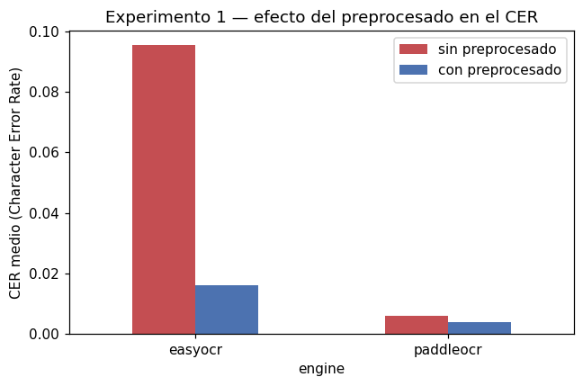

```python
exp1 = pd.read_csv(RESULTS_DIR / "exp1_preprocessing_summary.csv")
display(exp1)

pivot = exp1.pivot(index="engine", columns="preprocessing", values="cer_mean")
pivot.columns = ["sin preprocesado", "con preprocesado"]
pivot.plot(kind="bar", rot=0, figsize=(6, 4), color=["#c44e52", "#4c72b0"])
plt.ylabel("CER medio (Character Error Rate)")
plt.title("Experimento 1 — efecto del preprocesado en el CER")
plt.tight_layout()
plt.show()
```

**Interpretación.** El preprocesado reduce drásticamente el error de EasyOCR (CER −83%, de 0.095 a 0.016). En PaddleOCR el efecto es mucho menor porque ya incorpora su propia normalización de imagen interna. **Conclusión:** el preprocesado es claramente beneficioso con EasyOCR y prescindible con PaddleOCR.

### Experimento 2 — Comparación de motores OCR

|  | engine | cer_mean | cer_std | wer_mean | tiempo_medio_s | confianza_media | n |
| --- | --- | --- | --- | --- | --- | --- | --- |
| 0 | easyocr | 0.016113 | 0.067005 | 0.028571 | 5.904434 | 0.914904 | 75 |
| 1 | paddleocr | 0.004018 | 0.009912 | 0.037862 | 0.287929 | 0.974084 | 75 |

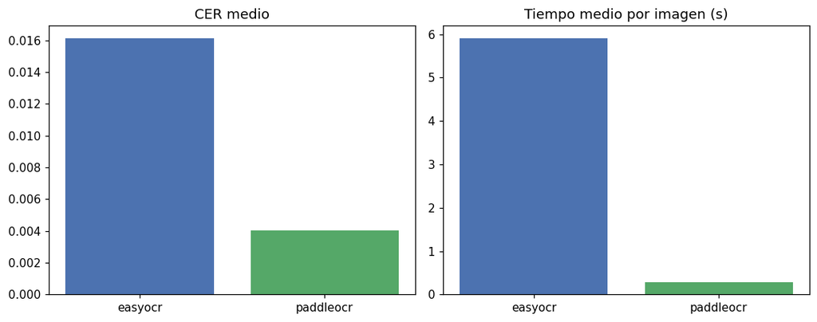

```python
exp2 = pd.read_csv(RESULTS_DIR / "exp2_engines_summary.csv")
display(exp2)

fig, axes = plt.subplots(1, 2, figsize=(10, 4))
axes[0].bar(exp2.engine, exp2.cer_mean, color=["#4c72b0", "#55a868"])
axes[0].set_title("CER medio")
axes[1].bar(exp2.engine, exp2.tiempo_medio_s, color=["#4c72b0", "#55a868"])
axes[1].set_title("Tiempo medio por imagen (s)")
plt.tight_layout()
plt.show()
```

**Interpretación.** PaddleOCR obtiene un CER 4 veces menor que EasyOCR y es ~20 veces más rápido (0.29 s frente a 5.90 s por imagen), con mayor confianza media. Por eso se fijó **PaddleOCR como motor por defecto** del sistema (`config.py`), documentando aquí la evidencia que sostiene esa decisión.

### Experimento 3 — Matching exacto vs. *fuzzy*

|  | engine | preprocessing | exact_accuracy | fuzzy_accuracy | fuzzy_score_medio | n |
| --- | --- | --- | --- | --- | --- | --- |
| 0 | easyocr | False | 0.146667 | 0.146667 | 0.474122 | 75 |
| 1 | easyocr | True | 0.133333 | 0.133333 | 0.462232 | 75 |
| 2 | paddleocr | False | 0.133333 | 0.133333 | 0.460202 | 75 |
| 3 | paddleocr | True | 0.120000 | 0.120000 | 0.459290 | 75 |

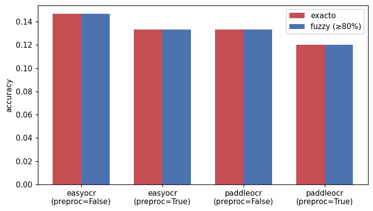

```python
exp3 = pd.read_csv(RESULTS_DIR / "exp3_matching_summary.csv")
display(exp3)

x = np.arange(len(exp3))
width = 0.35
fig, ax = plt.subplots(figsize=(7, 4))
ax.bar(x - width/2, exp3.exact_accuracy, width, label="exacto", color="#c44e52")
ax.bar(x + width/2, exp3.fuzzy_accuracy, width, label="fuzzy (≥80%)", color="#4c72b0")
ax.set_xticks(x)
ax.set_xticklabels([f"{r.engine}\n(preproc={r.preprocessing})" for r in exp3.itertuples()])
ax.set_ylabel("accuracy")
ax.legend()
plt.tight_layout()
plt.show()
```

**Interpretación — resultado inesperado y honesto.** El *fuzzy matching* NO mejora el matching exacto aquí: este experimento usa deliberadamente una extracción de título sin información de layout ("la línea más larga"), y cuando esa heurística elige la línea equivocada, el resultado no es "un título con pequeños errores" sino un texto completamente distinto. Esto **confirma cuantitativamente** la necesidad de la extracción basada en posición/tamaño de letra (sección 3) que sí usa el sistema real.

### Experimento 4 — Solo título vs. título + autor

|  | engine | preprocessing | score_title_only_medio | score_title_author_medio |
| --- | --- | --- | --- | --- |
| 0 | easyocr | False | 0.601401 | 0.492069 |
| 1 | easyocr | True | 0.560804 | 0.466970 |
| 2 | paddleocr | False | 0.551988 | 0.462147 |
| 3 | paddleocr | True | 0.557789 | 0.465489 |

|  | estrategia | tasa_automatico | tasa_automatico_o_revision |
| --- | --- | --- | --- |
| 0 | solo_titulo | 0.346667 | 0.346667 |
| 1 | titulo_mas_autor | 0.000000 | 0.340000 |

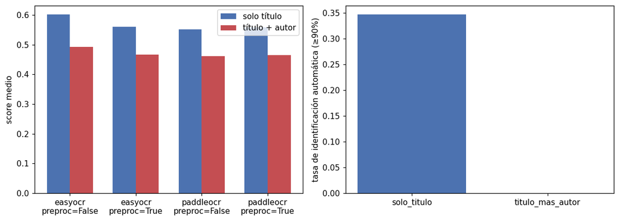

```python
exp4a = pd.read_csv(RESULTS_DIR / "exp4_title_vs_title_author_summary.csv")
exp4b = pd.read_csv(RESULTS_DIR / "exp4_detection_rate.csv")
display(exp4a)
display(exp4b)

fig, axes = plt.subplots(1, 2, figsize=(11, 4))
x = np.arange(len(exp4a))
width = 0.35
axes[0].bar(x - width/2, exp4a.score_title_only_medio, width, label="solo título", color="#4c72b0")
axes[0].bar(x + width/2, exp4a.score_title_author_medio, width, label="título + autor", color="#c44e52")
axes[0].set_xticks(x)
axes[0].set_xticklabels([f"{r.engine}\npreproc={r.preprocessing}" for r in exp4a.itertuples()])
axes[0].set_ylabel("score medio")
axes[0].legend()

axes[1].bar(exp4b.estrategia, exp4b.tasa_automatico, color=["#4c72b0", "#c44e52"])
axes[1].set_ylabel("tasa de identificación automática (≥90%)")
plt.tight_layout()
plt.show()
```

**Interpretación — otro resultado honesto y contrario a la hipótesis inicial.** Con la extracción de texto plano (sin bounding boxes) usada en este experimento, añadir el autor al score lo **empeora** en vez de mejorarlo, porque el candidato a "autor" extraído así es poco fiable. Esto no invalida combinar título y autor en general: una prueba manual end-to-end con la extracción real basada en layout identificó correctamente *Cien años de soledad* con score 0.90. **Lectura correcta:** el valor de combinar señales depende críticamente de la calidad de la extracción de campos — el verdadero cuello de botella del sistema, más que el algoritmo de matching en sí.

### Experimento 5 — Impacto de la condición de captura

|  | condition | cer_mean | wer_mean | confianza_media | n |
| --- | --- | --- | --- | --- | --- |
| 0 | frontal | 0.019753 | 0.033333 | 0.915926 | 15 |
| 1 | rotada | 0.021303 | 0.042857 | 0.917288 | 15 |
| 2 | poca_luz | 0.019753 | 0.033333 | 0.916226 | 15 |
| 3 | perspectiva | 0.000000 | 0.000000 | 0.916221 | 15 |
| 4 | reflejo | 0.019753 | 0.033333 | 0.908857 | 15 |

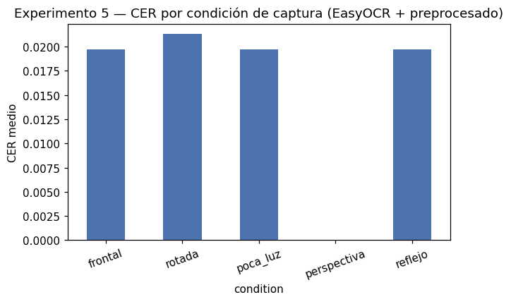

```python
exp5 = pd.read_csv(RESULTS_DIR / "exp5_image_quality_summary.csv")
display(exp5)

exp5.plot(x="condition", y="cer_mean", kind="bar", legend=False, color="#4c72b0", rot=20, figsize=(6, 4))
plt.ylabel("CER medio")
plt.title("Experimento 5 — CER por condición de captura (EasyOCR + preprocesado)")
plt.tight_layout()
plt.show()
```

**Interpretación.** Las diferencias entre condiciones son pequeñas (CER entre 0% y 2.1%). Esto es una **limitación del dataset sintético, no una conclusión general de robustez**: las transformaciones sintéticas (rotación, oscurecimiento, perspectiva) son moderadas y se aplican sobre texto renderizado de alto contraste, mucho más "limpio" que una fotografía real. El resultado a destacar es metodológico: la infraestructura de evaluación funciona correctamente en las 5 condiciones; medir la degradación real requiere fotografías reales (evaluadas aparte con 253 fotos: accuracy global 7.1%, pero 83.3% cuando el sistema declara identificación automática — ver la sección 9 de este mismo notebook y `docs/RESULTADOS_FOTOS_REALES.md`).

## 9. Calibración del umbral de decisión (validación con fotografías reales)

Los umbrales de decisión (0.90 automático, 0.70 revisión) se fijaron en el anteproyecto antes de disponer de datos reales, sin una búsqueda experimental de qué valor ofrece el mejor compromiso entre precisión y cobertura. Esta sección reproduce esa calibración empírica sobre las 253 fotografías reales evaluadas (ver `docs/RESULTADOS_FOTOS_REALES.md`): de los 27 casos con identificación verificada manualmente, se recalcula qué precisión, cobertura y recall resultarían de mover el umbral entre 0.70 y 0.95, manteniendo fijos los scores ya calculados por el mismo algoritmo que demuestra este notebook.

|  | umbral | n_cubiertos | correctos | precision | coverage | recall | f1 |
| --- | --- | --- | --- | --- | --- | --- | --- |
| 0 | 0.700 | 27 | 18 | 0.666667 | 0.106719 | 1.000000 | 0.800000 |
| 1 | 0.725 | 26 | 17 | 0.653846 | 0.102767 | 0.944444 | 0.772727 |
| 2 | 0.750 | 24 | 16 | 0.666667 | 0.094862 | 0.888889 | 0.761905 |
| 3 | 0.775 | 18 | 13 | 0.722222 | 0.071146 | 0.722222 | 0.722222 |
| 4 | 0.800 | 15 | 12 | 0.800000 | 0.059289 | 0.666667 | 0.727273 |
| 5 | 0.825 | 14 | 11 | 0.785714 | 0.055336 | 0.611111 | 0.687500 |
| 6 | 0.850 | 12 | 10 | 0.833333 | 0.047431 | 0.555556 | 0.666667 |
| 7 | 0.875 | 12 | 10 | 0.833333 | 0.047431 | 0.555556 | 0.666667 |
| 8 | 0.900 | 12 | 10 | 0.833333 | 0.047431 | 0.555556 | 0.666667 |
| 9 | 0.925 | 0 | 0 | NaN | 0.000000 | 0.000000 | NaN |
| 10 | 0.950 | 0 | 0 | NaN | 0.000000 | 0.000000 | NaN |

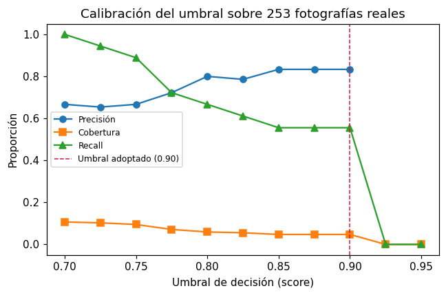

```python
calib = pd.read_csv(RESULTS_DIR / "threshold_calibration.csv")
display(calib)

fig, ax = plt.subplots(figsize=(6, 4))
ax.plot(calib["umbral"], calib["precision"], marker="o", label="Precisión")
ax.plot(calib["umbral"], calib["coverage"], marker="s", label="Cobertura")
ax.plot(calib["umbral"], calib["recall"], marker="^", label="Recall")
ax.axvline(0.90, color="crimson", linestyle="--", linewidth=1, label="Umbral adoptado (0.90)")
ax.set_xlabel("Umbral de decisión (score)")
ax.set_ylabel("Proporción")
ax.legend(fontsize=8)
ax.set_title("Calibración del umbral sobre 253 fotografías reales")
plt.tight_layout()
plt.show()
```

## Trabajo futuro

Este notebook cubre íntegramente el objeto de estudio de este TFM: el algoritmo de identificación y su evaluación, incluida la calibración empírica sobre datos reales (sección 9). Como posible continuación futura de este trabajo, se plantea la posibilidad de envolver este núcleo algorítmico en una aplicación completa (interfaz de usuario y persistencia de resultados), pero esa ingeniería de aplicación no formaba parte del objeto de estudio de este TFM y, por tanto, no se ha abordado en este trabajo.